# Group_8_Formal_Analysis

```
• Search for functions across packages at https://www.tidymodels.org/find/
```

```
Install package "strengejacke" from GitHub (`devtools::install_github("strengejacke/strengejacke")`) to load all sj-packages at once!
```

```
Call:
glm(formula = Obese ~ AgeGroup, family = binomial, data = data)

Coefficients:
              Estimate Std. Error z value Pr(>|z|)
(Intercept)   -1.73631    0.06170  -28.14  < 2e-16 ***
AgeGroup25-34  0.44453    0.07471    5.95 2.68e-09 ***
AgeGroup35-44  0.88317    0.06979   12.65  < 2e-16 ***
AgeGroup45-54  0.95485    0.06895   13.85  < 2e-16 ***
AgeGroup55-64  1.16308    0.06897   16.86  < 2e-16 ***
AgeGroup65-74  1.11899    0.07064   15.84  < 2e-16 ***
AgeGroup75+    0.81453    0.07792   10.45  < 2e-16 ***
---
Signif. codes:  0 '***' 0.001 '**' 0.01 '*' 0.05 '.' 0.1 ' ' 1

(Dispersion parameter for binomial family taken to be 1)

    Null deviance: 30649  on 25223  degrees of freedom
Residual deviance: 30150  on 25217  degrees of freedom
AIC: 30164

Number of Fisher Scoring iterations: 4
```

```
Call:
glm(formula = Obese ~ Sex, family = binomial, data = data)

Coefficients:
            Estimate Std. Error z value Pr(>|z|)
(Intercept) -0.85652    0.01850 -46.290   <2e-16 ***
SexMale     -0.02106    0.02776  -0.759    0.448
---
Signif. codes:  0 '***' 0.001 '**' 0.01 '*' 0.05 '.' 0.1 ' ' 1

(Dispersion parameter for binomial family taken to be 1)

    Null deviance: 30649  on 25223  degrees of freedom
Residual deviance: 30648  on 25222  degrees of freedom
AIC: 30652

Number of Fisher Scoring iterations: 4
```

```
Call:
glm(formula = Obese ~ Employment, family = binomial, data = data)

Coefficients:
                                                                 Estimate
(Intercept)                                                      -0.86824
EmploymentIn full-time education                                 -1.16236
EmploymentIn paid employment, self-employed or on gov't training -0.03470
EmploymentLooking after home/family                              -0.06153
EmploymentLooking for/intending to look for paid work            -0.12037
EmploymentPerm unable to work                                     0.41501
EmploymentRetired                                                 0.16511
                                                                 Std. Error
(Intercept)                                                         0.13239
EmploymentIn full-time education                                    0.16466
EmploymentIn paid employment, self-employed or on gov't training    0.13370
EmploymentLooking after home/family                                 0.14381
EmploymentLooking for/intending to look for paid work               0.15532
EmploymentPerm unable to work                                       0.14587
EmploymentRetired                                                   0.13500
                                                                 z value
(Intercept)                                                       -6.558
EmploymentIn full-time education                                  -7.059
EmploymentIn paid employment, self-employed or on gov't training  -0.260
EmploymentLooking after home/family                               -0.428
EmploymentLooking for/intending to look for paid work             -0.775
EmploymentPerm unable to work                                      2.845
EmploymentRetired                                                  1.223
                                                                 Pr(>|z|)
(Intercept)                                                      5.45e-11 ***
EmploymentIn full-time education                                 1.68e-12 ***
EmploymentIn paid employment, self-employed or on gov't training  0.79521
EmploymentLooking after home/family                               0.66875
EmploymentLooking for/intending to look for paid work             0.43834
EmploymentPerm unable to work                                     0.00444 **
EmploymentRetired                                                 0.22132
---
Signif. codes:  0 '***' 0.001 '**' 0.01 '*' 0.05 '.' 0.1 ' ' 1

(Dispersion parameter for binomial family taken to be 1)

    Null deviance: 30649  on 25223  degrees of freedom
Residual deviance: 30372  on 25217  degrees of freedom
AIC: 30386

Number of Fisher Scoring iterations: 4
```

```
[1] 12.59159
```

```
[1] 25587.53
```

The difference in the null and residual deviance is 499 and this is much larger than the 95th percentile of a chi-squared distribution on 6 degrees of freedom which is 12.59. Therefore it is worth including age in the model.

The baseline category for the binary response is not obese and the baseline category for age is 16-24. This means that estimates from the logistic regression model are for a change on the log-odds scale for being obese in comparison to the response baseline of not obese and for all other age groups in comparison to age group 16-24.

The model equation is

$$\mbox{ln}({\frac{p}{1-p}}) = \alpha + \beta \cdot\mbox{Age Group}= -1.73 + 0.44 \cdot \mathbb{I}_{\mbox{Age Group}}(\mbox{25-34}) + 0.88 \cdot \mathbb{I}_{\mbox{Age Group}}(\mbox{35-44}) + 0.95 \cdot \mathbb{I}_{\mbox{Age Group}}(\mbox{45-54}) + 1.16 \cdot \mathbb{I}_{\mbox{Age Group}}(\mbox{55-64})+ 1.11 \cdot \mathbb{I}_{\mbox{Age Group}}(\mbox{65-74}) + 0.81 \cdot \mathbb{I}_{\mbox{Age Group}}(\mbox{75+})$$

where $\mathbb{I}_{\mbox{Age Group}}$ is an indicator function

For example the log odds increase of being obese increase by 0.44 for people in the 25-34 age group.

The probabilities of being obese for each age group starting at age group 16-24 are

```
[1] 0.1497819
```

```
[1] 0.2155509
```

```
[1] 0.2987737
```

```
[1] 0.3140057
```

```
[1] 0.3604906
```

```
[1] 0.3503905
```

```
[1] 0.2845941
```

We can see the probability of being obese is highest for the 55-64 age group and lowest for the 16-24. We can plot the estimated probabilities by age group.

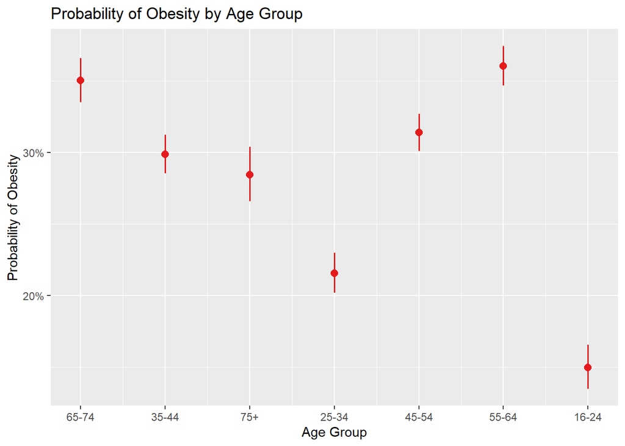

We can see that there is quite a lot of difference between the estimated probabilities of being obese in each group.
$$\mbox{ln}({\frac{p}{1-p}}) = \alpha + \beta \cdot\mbox{Sex}= -0.86 -0.02 \cdot \mathbb{I}_{\mbox{Sex}}(\mbox{Male})$$

```
[1] 0.2980659
```

```
[1] 0.293679
```

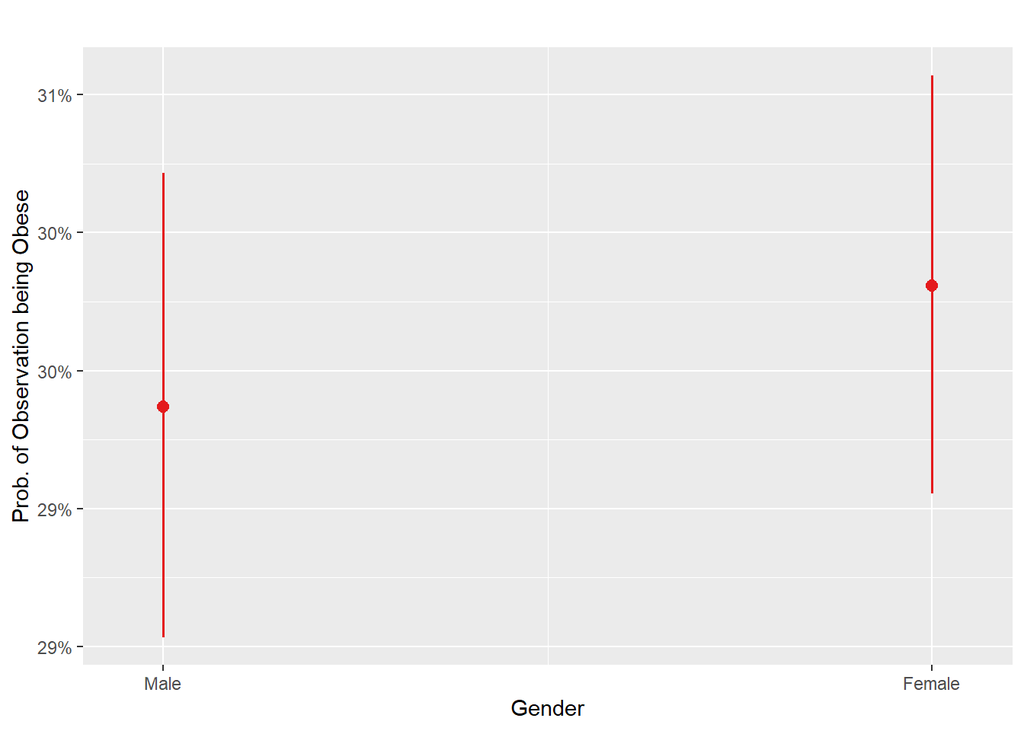

For socio-economic status we have the following model,

$$ln(\frac {p} {1-p}) = \alpha + -1.16 \cdot \mathbb{I}_{\mbox{Edu}}(x) + -0.03 \cdot \mathbb{I}_{\mbox{Emp}}(x) + -0.06 \cdot
\mathbb{I}_{\mbox{Home}}(x) + -0.12 \cdot \mathbb{I}_{\mbox{LFW}}(x) + 0.42 \cdot \mathbb{I}_{\mbox{Unable}}(x) + 0.17 \cdot \mathbb{I}_{\mbox{Retired}}(x)$$

where $\mathbb{I}_{\mbox{Edu}}(x)$, $\mathbb{I}_{\mbox{Emp}}(x)$, $\mathbb{I}_{\mbox{Home}}(x)$, $\mathbb{I}_{\mbox{LFW}}(x)$, $\mathbb{I}_{\mbox{Unable}}(x)$, $\mathbb{I}_{\mbox{Retired}}(x)$ are indicator functions such that: ‘Edu’ represents subjects in full-time education, ‘Emp’ represents paid employment, self-employment or government training, ‘Home’ represents looking after home or family, ‘LFW’ represents looking for work, ‘Unable’ represents unable to work and ‘Retired’ represents subjects that are retired.

We again have that the baseline category for the binary response is ‘not obese’ and the baseline for employment status is ‘Doing Something Else’. This means we can interpret the estimates from the logistic regression as the change in the log-odds scale for ‘obese’ compared to the baseline ‘not obese’ and for all other employment status in comparison to ‘Doing Something Else’.

The probability of being obese for each socio-economic status are

```
[1] 0.2956204
```

```
[1] 0.1160275
```

```
[1] 0.2884464
```

```
[1] 0.2829706
```

```
[1] 0.2711864
```

```
[1] 0.3885918
```

```
[1] 0.3311176
```

Here we see that the probability of being obese is highest for subjects that are permanently unable to work, it is lowest for subjects in full-time education.

[figure not shown]

From the plot we can see there appears to be a significant difference in the probability of being obese between different socio-economic groups.